# Phylogenetic tree manipulation

Silvia Castiglione, Carmela Serio, Pasquale Raia

## Index

1. tree.merger tool
   1. tree.merger basics
   2. Input tree and data
   3. Attaching individual tips to the backbone tree
   4. Attaching clades to the backbone tree
   5. Building a new tree
   6. Guided examples
2. scaleTree tool
3. move.lineage tool
4. cutPhylo tool
5. fix.poly tool

## tree.merger tool

### tree.merger basics

The function `tree.merger` was created to merge phylogenetic information derived from different phylogenies into a single supertree. Given a backbone (`backbone`) and a source (`source.tree`) trees, `tree.merger` drops clades from the latter to attach them on the former according to the information provided in the dataset object `data`. Individual tips to add can be indicated in `data` as well. The function has been subsequently implemented to build phylogenetic trees from scratch by only using the `data` object. In both cases, once the supertree is assembled, tips and nodes’ ages are calibrated based on user-specified values.

### Merging trees: input tree and data

The `backbone` phylogeny serves as the reference to locate where single tips or entire clades extracted from the `source.tree` have to be attached. The `backbone` is assumed to be correctly calibrated so that nodes and tips ages (including the age of the tree root) are left unchanged, unless the user specifies otherwise. The `source.tree` is the phylogeny from which the clades to add are extracted. For each clade attached to the `backbone`, the time distances between the most recent common ancestor of the clade and its descendant nodes are kept fixed, unless the ages for any of these nodes are indicated by the user. All the new tips added to the `backbone`, irrespective of whether they are attached as a clade or as individual tips, are placed at the maximum distance from the tree root, unless calibration ages are supplied by the user. The `data` object is a dataframe including information about “what” is attached, where and how. `data` must be made of three columns:

- **bind**: the tips or clades to be attached;
- **reference**: the tips or clades where **bind** will be attached;
- **poly**: a logical indicating whether the **bind** and **reference** pair should form a polytomy.

If different column names are supplied, `tree.merger` assumes they are ordered as described and eventually fails if this requirement is not met. Similarly, with duplicated **bind** supplied, the function stops and throws an error message. A clade, either to be bound or to be the reference, must be indicated by collating the names of the two phylogenetically furthest tips belonging to it, separated by the “-” symbol. Alternatively, if `backbone$node.label`/`source.tree$node.label` is not `NULL`, a **bind**/**reference** clade can be indicated as “Clade NAMEOFTHECLADE” when appropriate. Similarly, an entire genus on both the `backbone` and the `source.tree` can be indicated as “Genus NAMEOFTHEGENUS”. If the “Genus NAMEOFTHEGENUS” mode is used for a species/clade belonging to one or more different genera, the function automatically sets as reference the clade including all the species belonging to the reference genus, whatever they are already on the `backbone` or binded. Regardless the way it was attached, any ‘bound’ tip can be used as a reference for another tip (individually or as an element for clade identification, i.e. in the “species1-species2” form). The order with which clades and tips to attach are supplied does not matter.

Tips and nodes are calibrated within `tree.merger` by means of the function `scaleTree`. To this aim, named vectors of tips and nodes ages, meant as time distance from the youngest tips within the phylogeny, must be supplied. As for the `data` object, the nodes to be calibrated should be identified by collating the names of the two phylogenetically furthest tips it subtends to, separated by a “-”.

### Merging trees: Attaching individual tips to the backbone tree

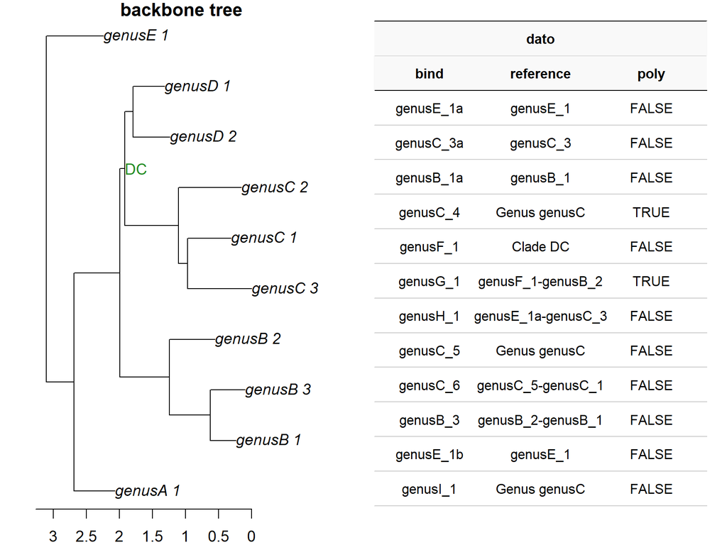

```
#> Warning in tree.merger(backbone = tree.back, data = dato, plot = FALSE): genusB_3 removed from the backbone tree
#> Warning in doTryCatch(return(expr), name, parentenv, handler): Root age not indicated: the tree root arbitrarily set at
#>  3.32
```

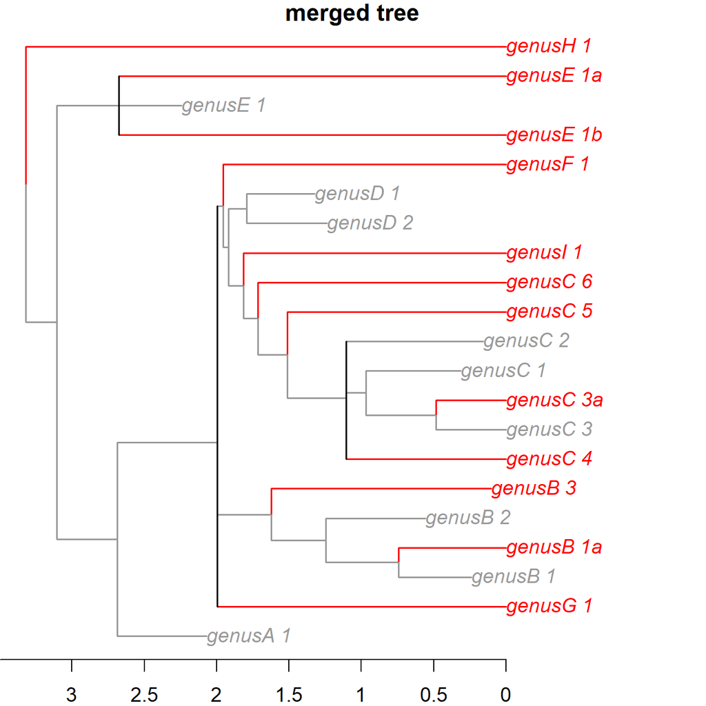

```r
tree.merger(backbone=tree.back,data=dato,plot=FALSE)
```

As no `tip.ages` are supplied to `tree.merger`, all the new tips are placed at the maximum distance from the tree root. Since no age for the root of the merged tree is indicated, the function places it arbitrarly and produces a warning to inform the user about its position with respect to the youngest tip on the phylogeny.

To calibrate the the ages of either tips or nodes within the merged tree, the arguments `tip.ages` and `node.ages` must be indicated.

```r
ages.tip
```

```
#>  genusH_1 genusE_1a  genusE_1 genusE_1b  genusF_1  genusC_5 genusC_3a  genusG_1
#>       1.0       2.0       1.7       1.5       0.8       1.5       0.3       1.2
#> genusB_1a
#>       0.2
```

```r
ages.node
```

```
#>   genusB_1-genusF_1 genusE_1a-genusE_1b   genusH_1-genusB_1
#>                 2.2                 2.9                 3.5
```

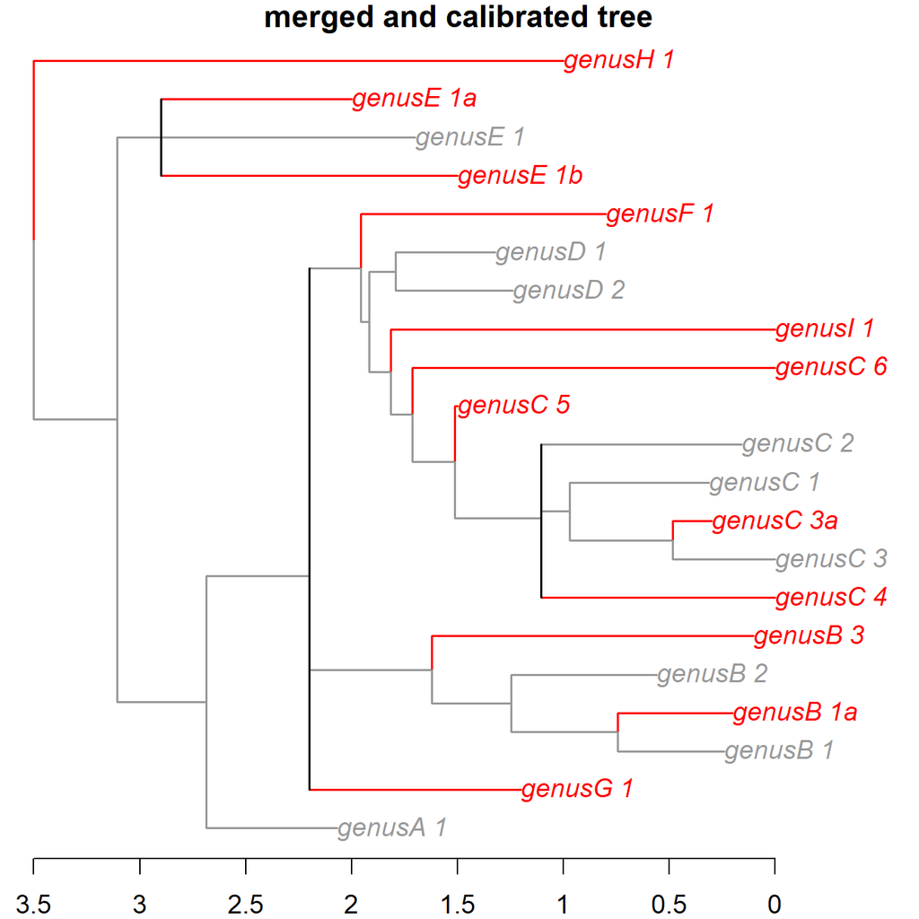

```r
tree.merger(backbone=tree.back,data=dato,tip.ages=ages.tip,node.ages = ages.node,plot=FALSE)
```

### Merging trees: Attaching clades to the backbone tree

When a clade is attached, the node subtending to it on `source.tree` is identified as the MRCA of the tip pair, the “Genus”, or the “Clade” indicated in **bind**. In the example below, “Genus genusA” from the source is added as sister to “genusA_1” within the backbone. Then, “genusL_1” is bound to the newly created clade made of all the tips belonging to the “genusA”, located by the two phylogenetically furthest tips within it.

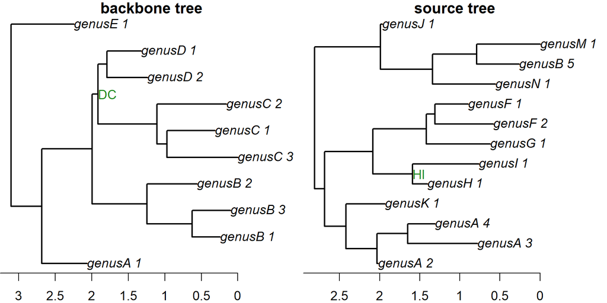

| dato.clade bind | dato.clade reference | dato.clade poly |
| --- | --- | --- |
| Genus genusA | genusA_1 | FALSE |
| genusG_1-genusF_2 | Clade DC | FALSE |
| Clade HI | Genus genusB | FALSE |
| genusL_1 | Genus genusA | FALSE |
| genusB_4 | genusB_3 | FALSE |
| genusM_1-genusN_1 | Genus genusB | FALSE |

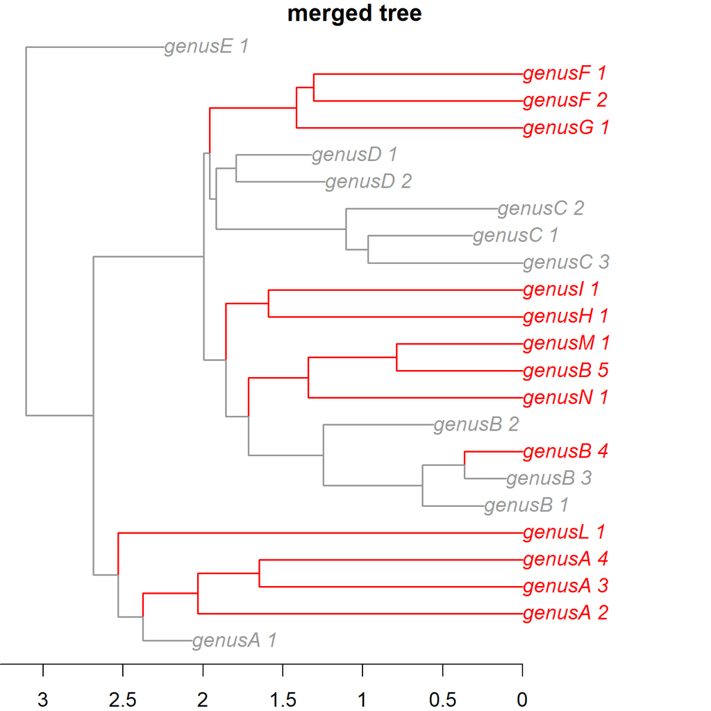

```r
tree.merger(backbone=tree.back,data=dato.clade,source.tree=tree.source,plot=FALSE)
```

### Building a new tree

The machinery described above works equally when `tree.merger` is used to build a new phylogenetic tree from scratch, with the only main difference that in this case the first row within `data` includes the first species pair to serve as *reference* for subsequent attachments. Additionally, since no a-priori information about species ages and tree height is available (unless provided), the function automatically produces an uncalibrated version of the tree where all the internal branch lengths equal 1 and all the species are placed at the maximum distance from the tree root.

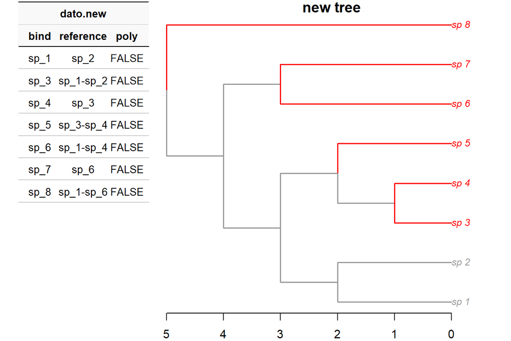

```r
tree.merger(data=dato.new,plot=FALSE)
```

### Guided examples

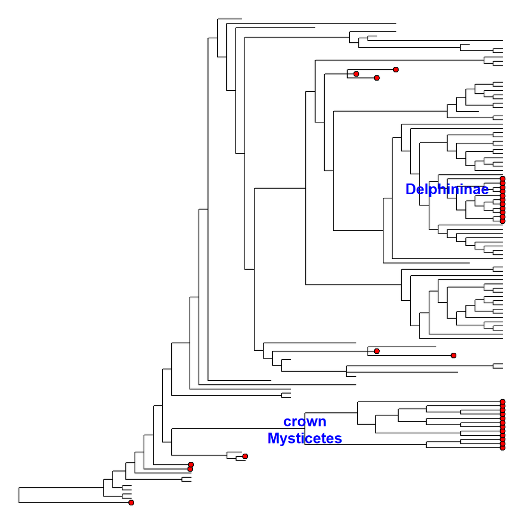

```r
#### Merging phylogenetic information
### load the RRphylo example dataset including Cetaceans tree
data("DataCetaceans")
DataCetaceans$treecet->treecet # phylogenetic tree
treecet$node.label[(131-Ntip(treecet))]<-"Crown Mysticeti" # assigning node labels

### Select two clades and some species to be removed
tips(treecet,131)->crown.Mysticetes
tips(treecet,193)->Delphininae
c("Aetiocetus_weltoni","Saghacetus_osiris",
  "Zygorhiza_kochii","Ambulocetus_natans",
  "Kentriodon_pernix","Kentriodon_schneideri","Kentriodon_obscurus",
  "Eurhinodelphis_cristatus","Eurhinodelphis_bossi")->extinct

plot(treecet,show.tip.label = FALSE,no.margin=TRUE)
nodelabels(frame="n",col="blue",font=2,node=c(131,193),text=c("crown\nMysticetes","Delphininae"))
tiplabels(frame="circle",bg="red",cex=.3,text=rep("",length(c(crown.Mysticetes,Delphininae,extinct))),
          tip=which(treecet$tip.label%in%c(crown.Mysticetes,Delphininae,extinct)))
```

```r
### Create the backbone and source trees
drop.tip(treecet,c(crown.Mysticetes[-which(tips(treecet,131)%in%
                                             c("Caperea_marginata","Eubalaena_australis"))],
                   Delphininae[-which(tips(treecet,193)=="Tursiops_aduncus")],extinct))->backtree
keep.tip(treecet,c(crown.Mysticetes,Delphininae,extinct))->sourcetree
```

| dato bind | dato reference | dato poly |
| --- | --- | --- |
| Clade Crown Mysticeti | Fucaia_buelli-Aetiocetus_weltoni | FALSE |
| Aetiocetus_weltoni | Aetiocetus_cotylalveus | FALSE |
| Saghacetus_osiris | Fucaia_buelli-Tursiops_truncatus | FALSE |
| Zygorhiza_kochii | Saghacetus_osiris-Fucaia_buelli | FALSE |
| Ambulocetus_natans | Dalanistes_ahmedi-Fucaia_buelli | FALSE |
| Genus Kentriodon | Phocoena_phocoena-Delphinus_delphis | FALSE |
| Sousa_chinensis-Delphinus_delphis | Sotalia_fluviatilis | FALSE |
| Kogia_sima | Kogia_breviceps | FALSE |
| Eurhinodelphis_cristatus | Eurhinodelphis_longirostris | FALSE |
| Grampus_griseus | Globicephala_melas-Pseudorca_crassidens | FALSE |
| Eurhinodelphis_bossi | Eurhinodelphis_longirostris | FALSE |

```r
### Merge the backbone and the source trees according to dato without calibrating tip and node ages
tree.merger(backbone = backtree,data=dato,source.tree = sourcetree,plot=FALSE)
### Set tips and nodes calibration ages
c(Aetiocetus_weltoni=28.0,
  Saghacetus_osiris=33.9,
  Zygorhiza_kochii=34.0,
  Ambulocetus_natans=40.4,
  Kentriodon_pernix=15.9,
  Kentriodon_schneideri=11.61,
  Kentriodon_obscurus=13.65,
  Eurhinodelphis_bossi=13.65,
  Eurhinodelphis_cristatus=5.33)->tipages
c("Ambulocetus_natans-Fucaia_buelli"=52.6,
  "Balaena_mysticetus-Caperea_marginata"=21.5)->nodeages

### Merge the backbone and the source trees and calibrate tips and nodes ages
tree.merger(backbone = backtree,data=dato,source.tree = sourcetree,
            tip.ages=tipages,node.ages=nodeages,plot=FALSE)
#### Building a new phylogenetic tree: build the phylogenetic tree shown in
#### Pandolfi et al. 2020 - Figure 2 (see reference)

### Create the data object
data.frame(bind=c("Hippopotamus_lemerlei",
                  "Hippopotamus_pentlandi",
                  "Hippopotamus_amphibius",
                  "Hippopotamus_antiquus",
                  "Hippopotamus_gorgops",
                  "Hippopotamus_afarensis",
                  "Hexaprotodon_sivalensis",
                  "Hexaprotodon_palaeindicus",
                  "Archaeopotamus_harvardi",
                  "Saotherium_mingoz",
                  "Choeropsis_liberiensis"),
           reference=c("Hippopotamus_madagascariensis",
                       "Hippopotamus_madagascariensis-Hippopotamus_lemerlei",
                       "Hippopotamus_pentlandi-Hippopotamus_madagascariensis",
                       "Hippopotamus_amphibius-Hippopotamus_madagascariensis",
                       "Hippopotamus_antiquus-Hippopotamus_madagascariensis",
                       "Hippopotamus_gorgops-Hippopotamus_madagascariensis",
                       "Genus Hippopotamus",
                       "Hexaprotodon_sivalensis",
                       "Hexaprotodon_sivalensis-Hippopotamus_madagascariensis",
                       "Archaeopotamus_harvardi-Hippopotamus_madagascariensis",
                       "Saotherium_mingoz-Hippopotamus_madagascariensis"),
           poly=c(FALSE,
                  TRUE,
                  FALSE,
                  FALSE,
                  TRUE,
                  FALSE,
                  FALSE,
                  FALSE,
                  FALSE,
                  FALSE,
                  FALSE))->dato
```

| bind | reference | poly |
| --- | --- | --- |
| Hippopotamus_lemerlei | Hippopotamus_madagascariensis | FALSE |
| Hippopotamus_pentlandi | Hippopotamus_madagascariensis-Hippopotamus_lemerlei | TRUE |
| Hippopotamus_amphibius | Hippopotamus_pentlandi-Hippopotamus_madagascariensis | FALSE |
| Hippopotamus_antiquus | Hippopotamus_amphibius-Hippopotamus_madagascariensis | FALSE |
| Hippopotamus_gorgops | Hippopotamus_antiquus-Hippopotamus_madagascariensis | TRUE |
| Hippopotamus_afarensis | Hippopotamus_gorgops-Hippopotamus_madagascariensis | FALSE |
| Hexaprotodon_sivalensis | Genus Hippopotamus | FALSE |
| Hexaprotodon_palaeindicus | Hexaprotodon_sivalensis | FALSE |
| Archaeopotamus_harvardi | Hexaprotodon_sivalensis-Hippopotamus_madagascariensis | FALSE |
| Saotherium_mingoz | Archaeopotamus_harvardi-Hippopotamus_madagascariensis | FALSE |
| Choeropsis_liberiensis | Saotherium_mingoz-Hippopotamus_madagascariensis | FALSE |

```r
### Build an uncalibrated version of the tree
tree.merger(data=dato,plot=FALSE)->tree.uncal
### Set tips and nodes calibration ages
## Please note: the following ages are only used to show how to use the function
## they are not assumed to be correct.
c("Hippopotamus_lemerlei"=0.001,
  "Hippopotamus_pentlandi"=0.45,
  "Hippopotamus_amphibius"=0,
  "Hippopotamus_antiquus"=0.5,
  "Hippopotamus_gorgops"=0.4,
  "Hippopotamus_afarensis"=0.75,
  "Hexaprotodon_sivalensis"=1,
  "Hexaprotodon_palaeindicus"=0.4,
  "Archaeopotamus_harvardi"=5.2,
  "Saotherium_mingoz"=4,
  "Choeropsis_liberiensis"=0)->tip.ages
c("Choeropsis_liberiensis-Hippopotamus_amphibius"=13,
  "Archaeopotamus_harvardi-Hippopotamus_amphibius"=8.5,
  "Hexaprotodon_sivalensis-Hexaprotodon_palaeindicus"=6)->node.ages


### Build a calibrated version of the tree
tree.merger(data=dato,tip.ages=tip.ages,node.ages=node.ages,plot=FALSE)->tree.cal
```

## scaleTree tool

The function `scaleTree` is a useful tool to deal with phylogenetic age calibration written around Gene Hunt’s scalePhylo function (https://naturalhistory.si.edu/staff/gene-hunt). It rescales branches and leaves of the tree according to species and/or nodes calibration ages (meant as distance from the youngest tip within the tree).

If only species ages are supplied (argument `tip.ages`), the function changes leaves length, leaving node ages and internal branch lengths unaltered. When node ages are supplied (argument `node.ages`), the function shifts nodes position along their own branches while keeping other nodes and species positions unchanged.

```r
sp.ages
```

```
#>    t9   t73   t11   t43   t78   t46   t52   t26
#> 1.250 1.205 0.000 2.430 3.150 1.050 0.000 1.550
```

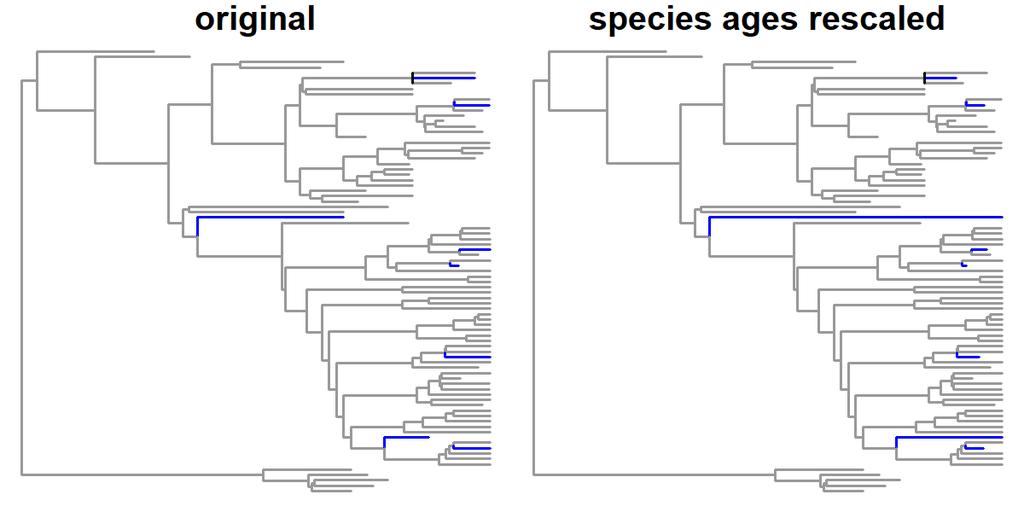

[output not shown]

```r
scaleTree(tree,tip.ages=sp.ages)->treeS1
```

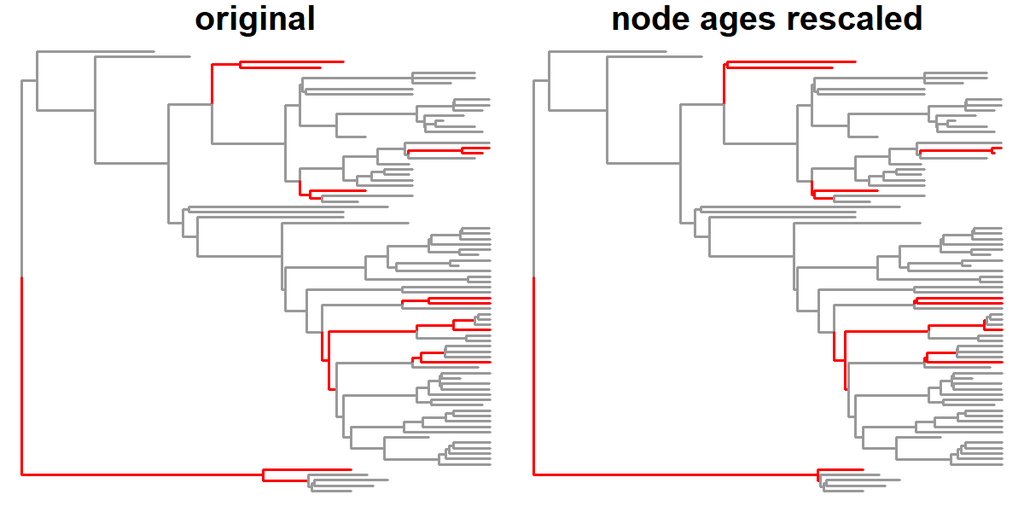

```r
scaleTree(tree,node.ages=nod.ages)->treeS2
```

It may happen that species and/or node ages to be calibrated are older than the age of their ancestors. In such cases, after moving the species (node) to its target age, the function reassembles the phylogeny above it by assigning the same branch length (set through the argument `min.branch`) to all the branches along the species (node) path, so that the tree is well-conformed and ancestor-descendants relationships remain unchanged. In this way changes to the original tree topology only pertain to the path along the “calibrated” species.

```r
c(sp.ages,nod.ages)
```

```
#>   t1   96
#> 20.5 15.6
```

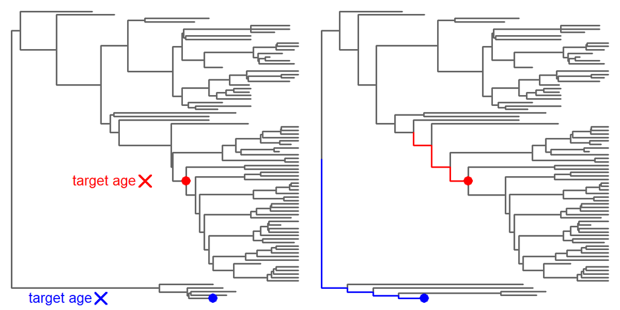

```r
scaleTree(tree,tip.ages = sp.ages,node.ages = nod.ages)->treeS
```